# Titanic Data Analysis

The sinking of the Titanic has been (and remains to this day) an unprecedented catastrophe, in terms both of human loss and the high profile and publicity surrounding the event. This analysis tells the story of this tragedy with data, most specifically with pandas and data frames. This analysis relies proponderently on descriptive statistics and visualisations, so it's conclusions should be treated as **tentantive**.

The question we want to ask is this: *Did any individual characteristics have any impact on survival so that certain individuals could stand higher chances of surviving in virtue of those characteristics?*

Let's import the relevant packages needed for analysis and preview the existing data.

```python
import pandas as pd
import numpy as np
import matplotlib.pyplot as plt
import seaborn as sns
%matplotlib inline
```

```python
dft = pd.read_csv('titanic-data.csv')
```

```python
dft.info()
```

```
<class 'pandas.core.frame.DataFrame'>
RangeIndex: 891 entries, 0 to 890
Data columns (total 12 columns):
PassengerId    891 non-null int64
Survived       891 non-null int64
Pclass         891 non-null int64
Name           891 non-null object
Sex            891 non-null object
Age            714 non-null float64
SibSp          891 non-null int64
Parch          891 non-null int64
Ticket         891 non-null object
Fare           891 non-null float64
Cabin          204 non-null object
Embarked       889 non-null object
dtypes: float64(2), int64(5), object(5)
memory usage: 83.6+ KB
```

A cursory glance over the columns of the dataframe suggests that only some of the existing passanger data is directly relevant to our analysis. Most specifically, we drop Passenger Id, Ticket, Cabin, Embark and Fare to keep things cleaner and work with a smaller (and easier to visualise) dataset. As the Age column contains missing data (i.e. more than 150 observations in the Age column contain NaNs) we replace the missing observations with the mean for the column.

```python
df = dft.drop(['PassengerId', 'Ticket', 'Cabin', 'Embarked', 'Fare'], axis = 1)
```

```python
df.info()
```

```
<class 'pandas.core.frame.DataFrame'>
RangeIndex: 891 entries, 0 to 890
Data columns (total 7 columns):
Survived    891 non-null int64
Pclass      891 non-null int64
Name        891 non-null object
Sex         891 non-null object
Age         714 non-null float64
SibSp       891 non-null int64
Parch       891 non-null int64
dtypes: float64(1), int64(4), object(2)
memory usage: 48.8+ KB
```

```python
df['Age'].fillna((df['Age'].mean()), inplace=True)
```

```python
df.head(20)
```

|  | Survived | Pclass | Name | Sex | Age | SibSp | Parch |
| --- | --- | --- | --- | --- | --- | --- | --- |
| 0 | 0 | 3 | Braund, Mr. Owen Harris | male | 22.000000 | 1 | 0 |
| 1 | 1 | 1 | Cumings, Mrs. John Bradley (Florence Briggs Th... | female | 38.000000 | 1 | 0 |
| 2 | 1 | 3 | Heikkinen, Miss. Laina | female | 26.000000 | 0 | 0 |
| 3 | 1 | 1 | Futrelle, Mrs. Jacques Heath (Lily May Peel) | female | 35.000000 | 1 | 0 |
| 4 | 0 | 3 | Allen, Mr. William Henry | male | 35.000000 | 0 | 0 |
| 5 | 0 | 3 | Moran, Mr. James | male | 29.699118 | 0 | 0 |
| 6 | 0 | 1 | McCarthy, Mr. Timothy J | male | 54.000000 | 0 | 0 |
| 7 | 0 | 3 | Palsson, Master. Gosta Leonard | male | 2.000000 | 3 | 1 |
| 8 | 1 | 3 | Johnson, Mrs. Oscar W (Elisabeth Vilhelmina Berg) | female | 27.000000 | 0 | 2 |
| 9 | 1 | 2 | Nasser, Mrs. Nicholas (Adele Achem) | female | 14.000000 | 1 | 0 |
| 10 | 1 | 3 | Sandstrom, Miss. Marguerite Rut | female | 4.000000 | 1 | 1 |
| 11 | 1 | 1 | Bonnell, Miss. Elizabeth | female | 58.000000 | 0 | 0 |
| 12 | 0 | 3 | Saundercock, Mr. William Henry | male | 20.000000 | 0 | 0 |
| 13 | 0 | 3 | Andersson, Mr. Anders Johan | male | 39.000000 | 1 | 5 |
| 14 | 0 | 3 | Vestrom, Miss. Hulda Amanda Adolfina | female | 14.000000 | 0 | 0 |
| 15 | 1 | 2 | Hewlett, Mrs. (Mary D Kingcome) | female | 55.000000 | 0 | 0 |
| 16 | 0 | 3 | Rice, Master. Eugene | male | 2.000000 | 4 | 1 |
| 17 | 1 | 2 | Williams, Mr. Charles Eugene | male | 29.699118 | 0 | 0 |
| 18 | 0 | 3 | Vander Planke, Mrs. Julius (Emelia Maria Vande... | female | 31.000000 | 1 | 0 |
| 19 | 1 | 3 | Masselmani, Mrs. Fatima | female | 29.699118 | 0 | 0 |

With a complete dataset with no missing values, let's look at the overall survival rate of all passengers aboard the Titanic:

```python
df['Survived'].value_counts(normalize=True)
```

```
0    0.616162
1    0.383838
Name: Survived, dtype: float64
```

With an overall survival rate of 38%, the prospect of surviving the Titanic disaster looked pretty grim. But is there any particular characteristic that increased these odds? Let's start by checking whether age had an impact on survival.

### Age & Survival

Let's look at some age-specific descriptive statistics first. Since we replaced missing values with the average age of all passengers, we expect the value counts for age to be skewed towards the column's mean value.

```python
df['Age'].mean()
```

```
29.69911764705882
```

```python
df['Age'].value_counts(normalize=True).head(10)
```

```
29.699118    0.198653
24.000000    0.033670
22.000000    0.030303
18.000000    0.029181
28.000000    0.028058
30.000000    0.028058
19.000000    0.028058
21.000000    0.026936
25.000000    0.025814
36.000000    0.024691
Name: Age, dtype: float64
```

```python
df['Age'].max()
```

```
80.0
```

```python
df['Age'].min()
```

```
0.41999999999999998
```

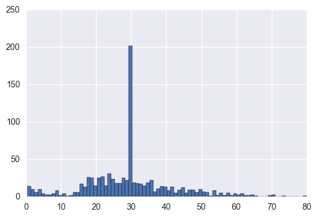

```python
df ['Age'].hist(bins=80)
```

It looks like most passangers on board the Titanic were young adults (between 20 to 30 years old), but the age spread is wide and ranges from 0.4 to 80 year olds.

To check whether age was relevant to survival, let's group the age data into three categories: children, adults and seniors. Let's examine whether two of these age groups, Children (i.e.men and women under the age of 18) and Seniors (i.e.men and women over the age of 65) stood higher or lower chances of survival.

```python
df['Child'] = df['Age'].apply(lambda age: age < 18)
```

```python
df['Child'].value_counts()
```

```
False    778
True     113
Name: Child, dtype: int64
```

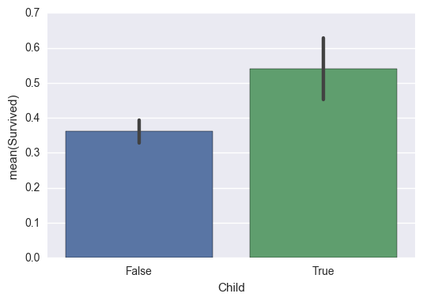

```python
sns.barplot(x="Child", y="Survived", data=df)
```

```python
df['Senior'] = df['Age'].apply(lambda age: age > 65)
```

```python
df['Senior'].value_counts()
```

```
False    883
True       8
Name: Senior, dtype: int64
```

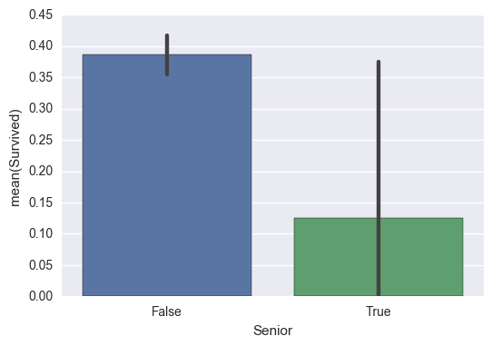

```python
sns.barplot(x="Senior", y="Survived", data=df)
```

Looking at the two bar plots above, the mean survival rate of children appears higher than the mean survival rate of non-children so being a child on board of the Titanic did seem to increase, even if slightly, one's likelihood of survival. In the case of seniors, that does not actually hold true, as the mean survival rate of seniors was lower than that of non-seniors.

But is there an significant correlation between being a child and surviving the Titanic disaster? Running the simple correlation below suggests that the correlation is not significant i.e. there is no linear relationship between the two variables. So while the number of children who survived is higher than those of non-children, it is not significant enough to assert that there is a necessary correlation between survival and age.

```python
df[['Survived', 'Child']].corr()
```

|  | Survived | Child |
| --- | --- | --- |
| Survived | 1.000000 | 0.122239 |
| Child | 0.122239 | 1.000000 |

### Gender & Survival

Being a child of a senior on board the Titanic did not seem to make much of a difference to survival. How about gender? Did survival depend on whether one was male or female?

A few descriptive statistics first.

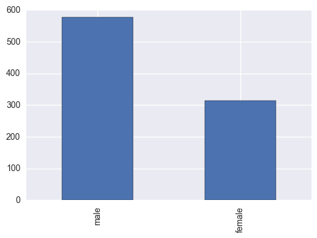

```python
df['Sex'].value_counts().plot(kind='bar')
```

```python
df[df['Sex'] =='female']['Survived'].value_counts(normalize=True)
```

```
1    0.742038
0    0.257962
Name: Survived, dtype: float64
```

```python
df[df['Sex'] =='male']['Survived'].value_counts(normalize=True)
```

```
0    0.811092
1    0.188908
Name: Survived, dtype: float64
```

While the total number of males on board the Titanic was significantly higher than that of females, the survival rates of males was much lower than that of females. Out of all males, only 19% of them survived, while of all females, 74% survived. But is the correlation between survival and gender statistically significant? Let's run a simple correlation to figure that out.

```python
df['sex_encoding'] = df['Sex'].apply(len)
```

```python
df[['Survived', 'sex_encoding']].corr(method='pearson')
```

|  | Survived | sex_encoding |
| --- | --- | --- |
| Survived | 1.000000 | 0.543351 |
| sex_encoding | 0.543351 | 1.000000 |

There is indeed a moderately strong correlation between sex and survival, so that it does seem to be the case that survival was likelier if one was female than if one was male. That finding seems to match the intuition (and what we otherwise know about the aftermath of the event) that females were boarded on rescue boats first, so that the number of females who made it to the shore was ultimately higher than that of males.

### The combined effect of Gender and Age on Survival

Let's draw a barplot to visualise the mean survival rate of both gender and age:

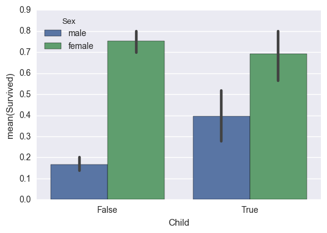

```python
sns.barplot(x="Child", y="Survived", hue="Sex", data=df)
```

It seems straightforward from the above that the survival rates of women were significantly higher than those of males, whether those females were children or adults. What is interesting though is that the mean survival rate of girls was lower than that of adult women, which suggests again that being a child had a weaker effect on survival than being a female.

### Title & Survival

```python
df['Name'].iloc[0].split()[1]
```

```
'Mr.'
```

```python
df['Title'] = df['Name'].apply(lambda name: name.split()[1])
```

```python
df['Title'].value_counts().head(6)
```

```
Mr.        502
Miss.      179
Mrs.       121
Master.     40
Dr.          7
Rev.         6
Name: Title, dtype: int64
```

```python
df[df['Title'] == 'Miss.']['Survived'].value_counts(normalize=True)
```

```
1    0.703911
0    0.296089
Name: Survived, dtype: float64
```

```python
df[df['Title'] == 'Mr.']['Survived'].value_counts(normalize=True)
```

```
0    0.842629
1    0.157371
Name: Survived, dtype: float64
```

```python
df[df['Title'] == 'Mrs.']['Survived'].value_counts(normalize=True)
```

```
1    0.801653
0    0.198347
Name: Survived, dtype: float64
```

```python
df[df['Title'] == 'Master.']['Survived'].value_counts(normalize=True)
```

```
1    0.575
0    0.425
Name: Survived, dtype: float64
```

```python
df[df['Title'] == 'Dr.']['Survived'].value_counts(normalize=True)
```

```
0    0.571429
1    0.428571
Name: Survived, dtype: float64
```

```python
df[df['Title'] == 'Rev.']['Survived'].value_counts()
```

```
0    6
Name: Survived, dtype: int64
```

```python
df[df['Title'] == 'Rev.']['Survived'].value_counts(normalize=True)
```

```
0    1.0
Name: Survived, dtype: float64
```

Looking at the survival rates above, there are a few unsurprising findings and a few interesting ones. It looks like the titles Miss and Mrs have high percentages of survival (70% and 80% respectively) which pretty much mirrors the findings we had when checking whether gender was relevant to survival. Similarly, the percentage rates of survival for Mr and Master are lower which again matches what we found earlier. What is interesting however is that all those with the title Reverend (i.e. 6 passengers on board) have all died. This seems to tell an interesting story about moral/religious convictions and how people who share those convictions are perhaps more likely to put others' survival ahead of their own. The data is, however, insufficient to derive a causal story, but it's a preliminary finding that seems too interesting not to point out. :)

### Passenger Class & Survival

As Passenger Class is likely (or standardly) indicative of wealth and status, it seems interesting to check whether survival is correlated with it. Let's check a few descriptive statistics about the number of people who checked in first, second and third class.

```python
df.groupby('Pclass').describe()
```

| Pclass |  | Age | Parch | SibSp | Survived | sex_encoding |
| --- | --- | --- | --- | --- | --- | --- |
| 1 | count | 216.000000 | 216.000000 | 216.000000 | 216.000000 | 216.000000 |
|  | mean | 37.048118 | 0.356481 | 0.416667 | 0.629630 | 4.870370 |
|  | std | 14.046369 | 0.693997 | 0.611898 | 0.484026 | 0.993866 |
|  | min | 0.920000 | 0.000000 | 0.000000 | 0.000000 | 4.000000 |
|  | 25% | 29.000000 | 0.000000 | 0.000000 | 0.000000 | 4.000000 |
|  | 50% | 35.000000 | 0.000000 | 0.000000 | 1.000000 | 4.000000 |
|  | 75% | 47.250000 | 0.000000 | 1.000000 | 1.000000 | 6.000000 |
|  | max | 80.000000 | 4.000000 | 3.000000 | 1.000000 | 6.000000 |
| 2 | count | 184.000000 | 184.000000 | 184.000000 | 184.000000 | 184.000000 |
|  | mean | 29.866958 | 0.380435 | 0.402174 | 0.472826 | 4.826087 |
|  | std | 13.573825 | 0.690963 | 0.601633 | 0.500623 | 0.987448 |
|  | min | 0.670000 | 0.000000 | 0.000000 | 0.000000 | 4.000000 |
|  | 25% | 23.000000 | 0.000000 | 0.000000 | 0.000000 | 4.000000 |
|  | 50% | 29.699118 | 0.000000 | 0.000000 | 0.000000 | 4.000000 |
|  | 75% | 36.000000 | 1.000000 | 1.000000 | 1.000000 | 6.000000 |
|  | max | 70.000000 | 3.000000 | 3.000000 | 1.000000 | 6.000000 |
| 3 | count | 491.000000 | 491.000000 | 491.000000 | 491.000000 | 491.000000 |
|  | mean | 26.403259 | 0.393075 | 0.615071 | 0.242363 | 4.586558 |
|  | std | 10.815245 | 0.888861 | 1.374883 | 0.428949 | 0.911459 |
|  | min | 0.420000 | 0.000000 | 0.000000 | 0.000000 | 4.000000 |
|  | 25% | 20.250000 | 0.000000 | 0.000000 | 0.000000 | 4.000000 |
|  | 50% | 29.699118 | 0.000000 | 0.000000 | 0.000000 | 4.000000 |
|  | 75% | 29.699118 | 0.000000 | 1.000000 | 0.000000 | 6.000000 |
|  | max | 74.000000 | 6.000000 | 8.000000 | 1.000000 | 6.000000 |

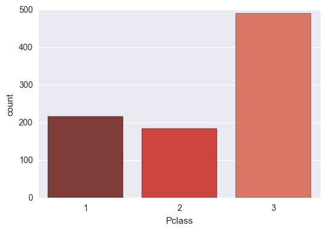

```python
sns.countplot(x="Pclass", data=df, palette="Reds_d")
```

```python
df ['Pclass'].value_counts(normalize=True)
```

```
3    0.551066
1    0.242424
2    0.206510
Name: Pclass, dtype: float64
```

```python
df[df['Pclass'] == 1]['Survived'].value_counts(normalize=True)
```

```
1    0.62963
0    0.37037
Name: Survived, dtype: float64
```

```python
df[df['Pclass'] == 2] ['Survived'].value_counts(normalize=True)
```

```
0    0.527174
1    0.472826
Name: Survived, dtype: float64
```

```python
df[df['Pclass'] == 3] ['Survived'].value_counts(normalize=True)
```

```
0    0.757637
1    0.242363
Name: Survived, dtype: float64
```

Unsurprisingly, the great majority of passengers (almost 500 people and about 55% of all passengers) checked in third class and it does seem interesting that the survival rates of those in third class are the lowest. While 62% of people who bought first class tickets and 47% of people who bought second class tickets survived, only 24% of people who travelled third class actually survived. This seems to point to some correlation between class and survival, but can we be sure that this is not just noise? Let's draw below visualisation of the mean survival with the combined effect of gender and class:

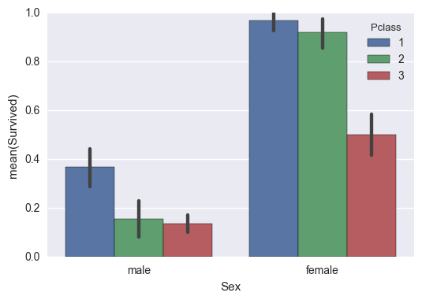

```python
sns.barplot(x="Sex", y="Survived", hue="Pclass", data=df)
```

While class does seem to make a difference to survival regardless of one's gender (i.e. mean survival is higher for those in first class regardless whether they were male or female), class seems to have a weaker effect than gender does. The barplot above makes pretty clear that the mean survival rates of women were significantly higher than those of males, regardless what passenger class they were in. Let's run a simple correlation to see whether that is indeed the case:

```python
df[['Survived', 'Pclass']].corr()
```

|  | Survived | Pclass |
| --- | --- | --- |
| Survived | 1.000000 | -0.338481 |
| Pclass | -0.338481 | 1.000000 |

The correlation results above show a weak negative linear relationship between class and survival so while class does seem to have an impact on survival it is, all things considered, a weak one.

### Number of Siblings and Spouses & Survival

Does the number of siblings and spouses on board affect survival? An initial intuition is that it might, as people with the highest number of family members on board might be the ones who would not want to leave their relatives behind and the least likely to rush to save themselves first. But let's see if this theoretical intuition holds true and look at a few descriptive stats first.

```python
df['SibSp'].value_counts(normalize=True)
```

```
0    0.682379
1    0.234568
2    0.031425
4    0.020202
3    0.017957
8    0.007856
5    0.005612
Name: SibSp, dtype: float64
```

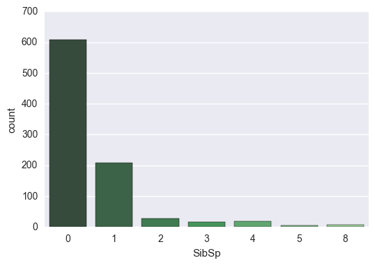

```python
sns.countplot(x="SibSp", data=df, palette="Greens_d")
```

```python
SipSp_perc = dft[["SibSp", "Survived"]].groupby(['SibSp']).mean()
```

```python
SipSp_perc
```

| SibSp | Survived |
| --- | --- |
| 0 | 0.345395 |
| 1 | 0.535885 |
| 2 | 0.464286 |
| 3 | 0.250000 |
| 4 | 0.166667 |
| 5 | 0.000000 |
| 8 | 0.000000 |

```python
df[df['SibSp'] == df['SibSp'].max()]
```

|  | Survived | Pclass | Name | Sex | Age | SibSp | Parch | Child | Senior | sex_encoding | Title |
| --- | --- | --- | --- | --- | --- | --- | --- | --- | --- | --- | --- |
| 159 | 0 | 3 | Sage, Master. Thomas Henry | male | 29.699118 | 8 | 2 | False | False | 4 | Master. |
| 180 | 0 | 3 | Sage, Miss. Constance Gladys | female | 29.699118 | 8 | 2 | False | False | 6 | Miss. |
| 201 | 0 | 3 | Sage, Mr. Frederick | male | 29.699118 | 8 | 2 | False | False | 4 | Mr. |
| 324 | 0 | 3 | Sage, Mr. George John Jr | male | 29.699118 | 8 | 2 | False | False | 4 | Mr. |
| 792 | 0 | 3 | Sage, Miss. Stella Anna | female | 29.699118 | 8 | 2 | False | False | 6 | Miss. |
| 846 | 0 | 3 | Sage, Mr. Douglas Bullen | male | 29.699118 | 8 | 2 | False | False | 4 | Mr. |
| 863 | 0 | 3 | Sage, Miss. Dorothy Edith "Dolly" | female | 29.699118 | 8 | 2 | False | False | 6 | Miss. |

While most passengers on board had no siblings, the survival rates seem highest for the group with one sibling/spouse on board. Interestingly though, the passengers with the highest number relatives on-board (who are, by the way, all related as they share the same last name) did not survive, which seem to hint at the intuition that 'siblings/spouses don't let their siblings/spouses die' might contain a grain of truth.

Drawing a barplot of the combined effect of SibSp and Sex below suggest that the sibling/spouse effect is much lower than the gender effect as the mean survival rates are much more sensitive to gender differences than to a difference in the number of siblings/spouses on-board.

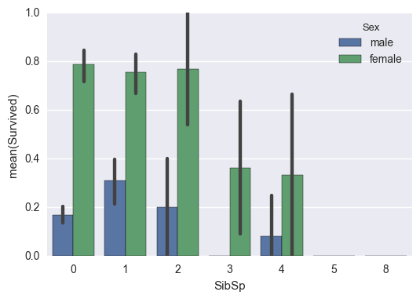

```python
sns.barplot(x="SibSp", y="Survived", hue="Sex", data=df)
```

Indeed, running a simple correlation between survival and number of siblings/spouses suggests that the effect of Sibsp is too weak to be significant so there is no relevant correlation between the two.

```python
df[['Survived', 'SibSp']].corr()
```

|  | Survived | SibSp |
| --- | --- | --- |
| Survived | 1.000000 | -0.035322 |
| SibSp | -0.035322 | 1.000000 |

### The Impact of Parch on Survival

Does the number of parents and children on-board affect survival? My initial intuition is similar to the one around SipSp so that people with the highest number of parents/children on board might be the ones who would not want to leave their relatives behind and the least likely to rush to save themselves first. But let's see if this theoretical intuition holds true and look at a few descriptive stats first.

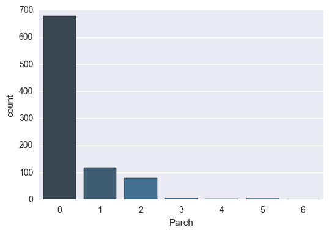

```python
sns.countplot(x="Parch", data=df, palette="Blues_d")
```

```python
Parch_perc = dft[["Parch", "Survived"]].groupby(['Parch']).mean()
```

```python
Parch_perc
```

| Parch | Survived |
| --- | --- |
| 0 | 0.343658 |
| 1 | 0.550847 |
| 2 | 0.500000 |
| 3 | 0.600000 |
| 4 | 0.000000 |
| 5 | 0.200000 |
| 6 | 0.000000 |

```python
df[df['Parch'] == df['Parch'].max()]
```

|  | Survived | Pclass | Name | Sex | Age | SibSp | Parch | Child | Senior | sex_encoding | Title |
| --- | --- | --- | --- | --- | --- | --- | --- | --- | --- | --- | --- |
| 678 | 0 | 3 | Goodwin, Mrs. Frederick (Augusta Tyler) | female | 43.0 | 1 | 6 | False | False | 6 | Mrs. |

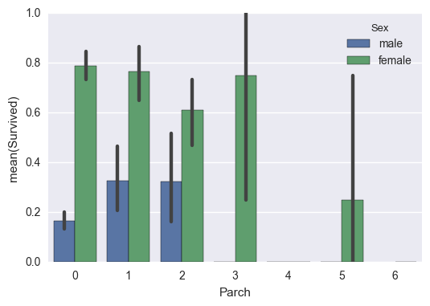

```python
sns.barplot(x="Parch", y="Survived", hue="Sex", data=df)
```

```python
df[['Survived', 'Parch']].corr()
```

|  | Survived | Parch |
| --- | --- | --- |
| Survived | 1.000000 | 0.081629 |
| Parch | 0.081629 | 1.000000 |

The correlation coefficient above does not seem to suggest that a correlation exists so that the number of parents/children on-board does not seem to have an effect on survival.

### Conclusion

Perhaps unsurprisingly, knowing what we now know about the Titanic disaster, only two things made a difference to one's survival: one's gender and one's wealth/status as reflected in the passenger class. Being female made the most significant difference as females were the first to make it safe to the shore. Passenger Class seem to have mattered to some extent as well, as the people with resources probably had an advantage in accessing the few available rescue boats. What is surprising however, is that we couldn't have a significant correlation between age and survival, although the mean rate of survival among children was higher than the mean survival rate of adults.